# Encuesta microestablecimientos 2016

David Moreno, Santiago Amado, Yodid Cardenas

Maestría en Ciencia de Datos

Modelos Estadísticos Aplicados

# 1 Contextualización.

**Contextualización de datos:**

El conjunto de datos de microestablecimientos 2016 se recopila con el objetivo de analizar las características y el desempeño económico de las pequeñas unidades productivas en el país. La base de datos incluye una amplia gama de información que abarca aspectos financieros, laborales y tecnológicos de los microestablecimientos, permitiendo así un análisis detallado de su estructura y comportamiento en el mercado. Las fuentes de información provienen principalmente de encuestas realizadas a los microempresarios y registros administrativos, cubriendo diferentes sectores económicos a nivel nacional. La base de datos cuenta con más de 100 variables que representan desde ingresos anuales hasta el uso de tecnología, como la existencia de una página web.

En términos de cobertura, la base de datos abarca microestablecimientos de diferentes regiones del país, permitiendo así un análisis geográfico y sectorial de los mismos. Las unidades de análisis son los microestablecimientos, definidos como pequeñas empresas que tienen un número limitado de empleados y recursos financieros, pero que representan un sector importante de la economía local. El muestreo utilizado es probabilístico, lo que garantiza que los resultados sean representativos de la población de microestablecimientos a nivel nacional. La información recolectada incluye variables cuantitativas, como los ingresos y gastos, y cualitativas, como el tipo de propiedad o el sector de actividad.

El objetivo del análisis estadístico que presentamos en este informe es identificar patrones de comportamiento entre los microestablecimientos en términos de ingresos, inversión en tecnología y capacidad laboral, con el fin de ofrecer recomendaciones sobre cómo estos negocios pueden mejorar su productividad y sostenibilidad. También se busca entender el impacto de la formalización y la adopción de tecnología en el desempeño de los microestablecimientos, lo que puede ayudar a orientar políticas públicas que fomenten el crecimiento de este sector en la economía.

# 2 Elección de variables.

```
##      Código.DANE                                              Descripción
## 1          P1010 Valor total de ventas o ingresos en los últimos 12 meses
## 2          P2532                      El establecimiento tiene página web
## 3          P1087              Número de computadores de escritorio en uso
## 4          P1088                 Número de computadores portátiles en uso
## 5          P1057                    Mes de referencia del valor reportado
## 6          P1092        Dispositivos PDA/DMC en uso en el establecimiento
## 7          P2524                    Acceso o uso del servicio de Internet
## 8          P1093               Uso de Internet dentro del establecimiento
## 9          P1006                   Actividades en las que se usa Internet
## 10         P1764                                 Formas de pago aceptadas
## 11         P1094                Uso de Internet fuera del establecimiento
## 12 CDGO_DPRTMNTO               Código de departamento del establecimiento
```

# 3 Justificacion de Variables

Hemos seleccionado estas 12 variables porque consideramos que nos ofrecen una visión integral del desempeño de los microestablecimientos en Colombia. A continuación, explicamos cada una y su relevancia en el análisis.

**P1010 (Ventas o ingresos en los últimos 12 meses):** Es clave para medir el desempeño financiero de los establecimientos.

**P2532 (Página web):** Evaluamos la adopción tecnológica, importante para la visibilidad y competitividad.

**P1087 (Computadores de escritorio):** Reflejan el nivel tecnológico disponible.

**P1088 (Computadores portátiles):** Reflejan el nivel tecnológico disponible.

**P1057 (Mes de referencia):** Nos ayuda a contextualizar los datos financieros.

**P1092 (Dispositivos PDA/DMC):** Mide el uso de dispositivos tecnológicos avanzados.

**P2524 (Acceso a Internet):** Fundamental para analizar la modernización del negocio.

**P1093 (Uso de Internet dentro del establecimiento):** Permiten evaluar la conectividad y productividad.

**P1094 (Uso fuera del establecimiento):** Permiten evaluar la conectividad y productividad.

**P1006 (Uso de Internet en actividades clave):** Nos permite conocer cómo la tecnología se integra en las operaciones diarias.

**P1764 (Formas de pago):** Es crucial para analizar la capacidad del establecimiento de gestionar transacciones modernas.

**CDGO_DPRTMNTO (Código de departamento):** Ayuda a contextualizar geográficamente los establecimientos, permitiendo análisis regionales (por ejemplo, el costo de la energía eléctrica).

# 4 Análisis descriptivo.

```
## Valores NA en P1010: 0
```

```
## Media: 97078679
```

```
## Mediana: 4.7e+07
```

```
## Desviación Estándar: 193160240
```

```
## Varianza: 3.731088e+16
```

```
##      Min.   1st Qu.    Median      Mean   3rd Qu.      Max.
## 2.000e+04 1.920e+07 4.700e+07 9.708e+07 1.000e+08 5.000e+09
```

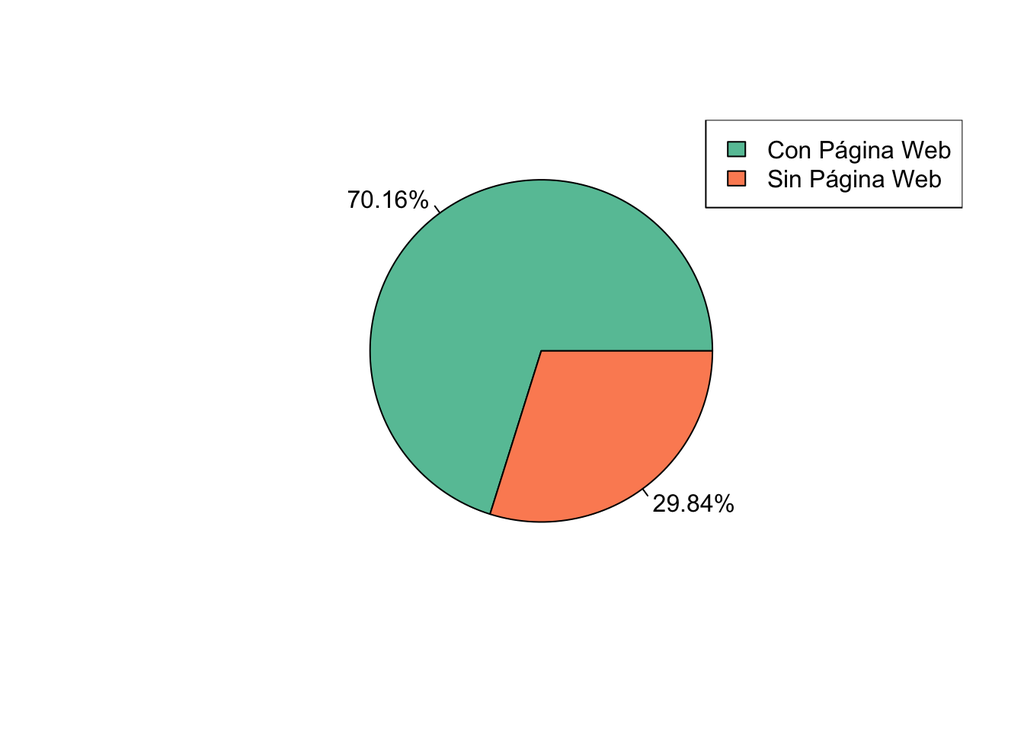

```
## Ventas medias en porcentajes relevantes a la variable *cuenta o no con página web* en la empresa.
## Este pie muestra que aquellas empresas que tienen página web tienen ventas medias mayores. Esto no implica que el internet sea de por sí la variable que impacte el desempeño de estas empresas. Es posible que estas empresas tengan más recursos para poder invertir en tecnología.
```

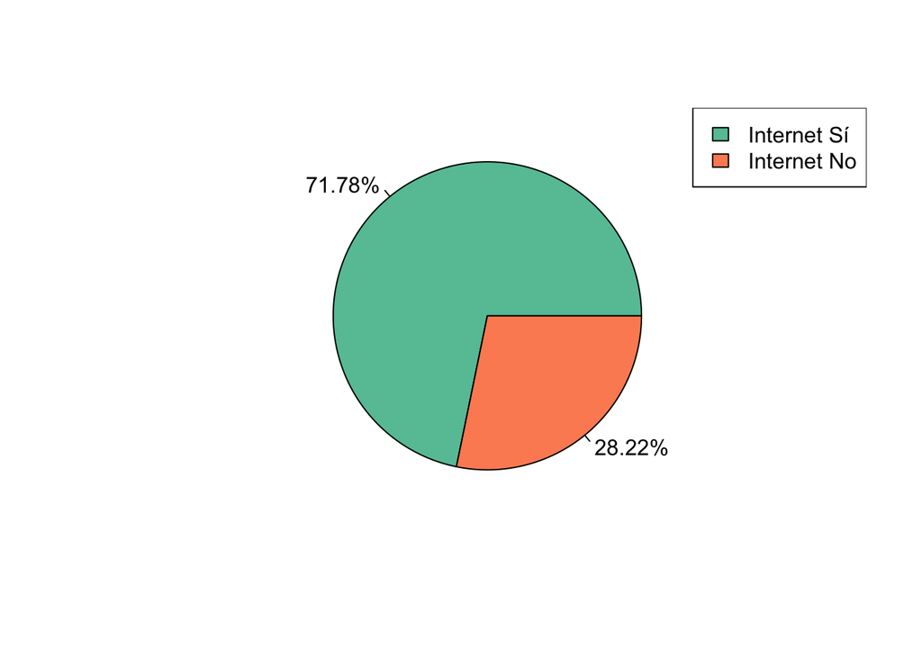

```
## Ventas medias en porcentajes relevantes a la variable *tiene o no internet* en la empresa.
## Este pie muestra que aquellas empresas que cuentan con internet tienen mayores ventas promedio que las que no. Comparada esta gráfica con la anterior, vemos que el tener internet en la empresa, con respecto a si tienen o no página web,
## presenta un incremento de más de un punto porcentual, i.e. de 70.16% a 71.78%. Esto indica que efectivamente puede ser más importante
## tener internet que contar con página web. Sin embargo, hay una gran diferencia con aquellas empresas que no tienen ni internet ni página web.
```

[figure not shown]

[output not shown]

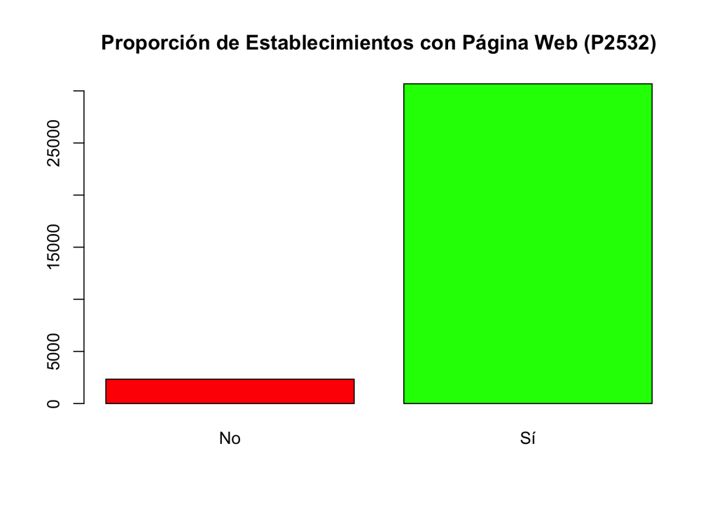

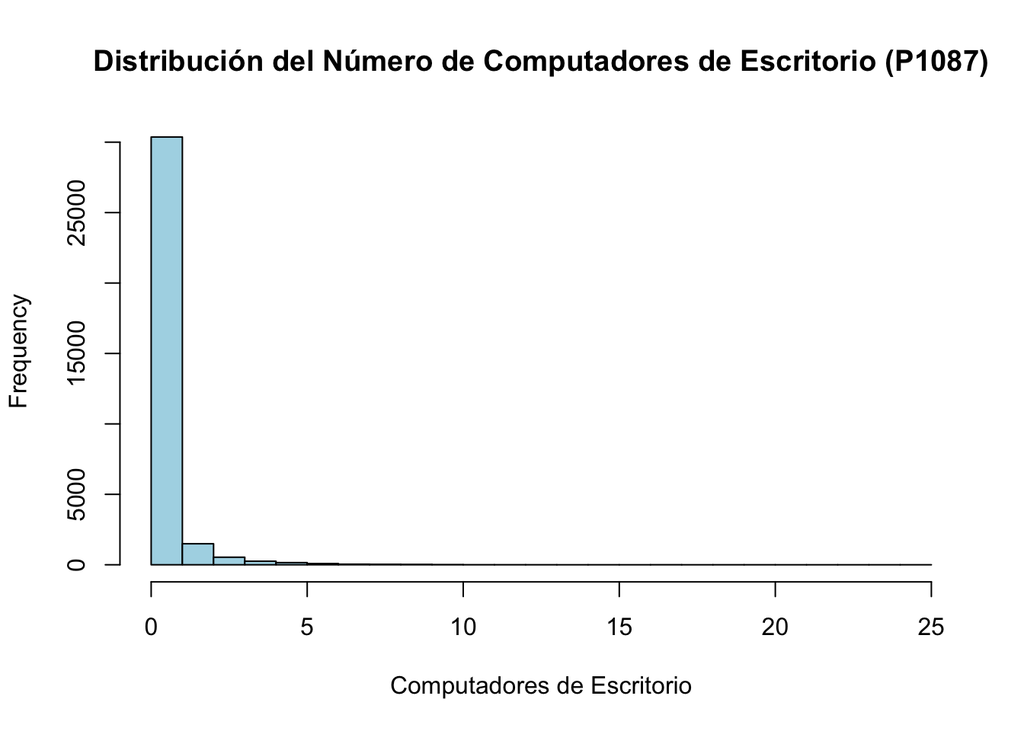

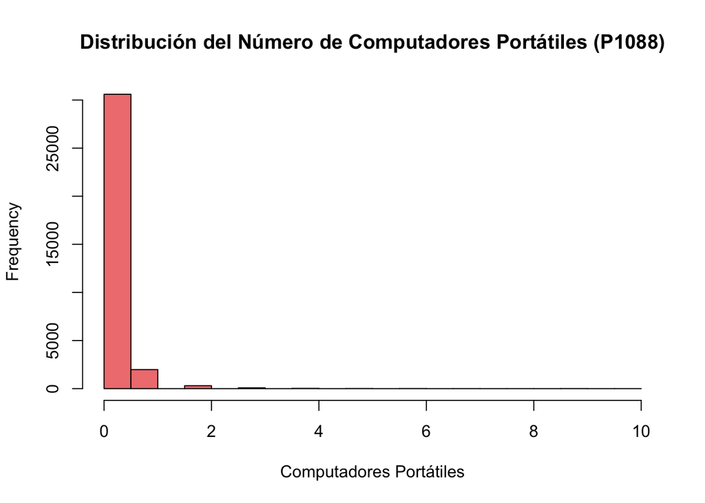

# 5 Distribución del total de ventas o ingresos.

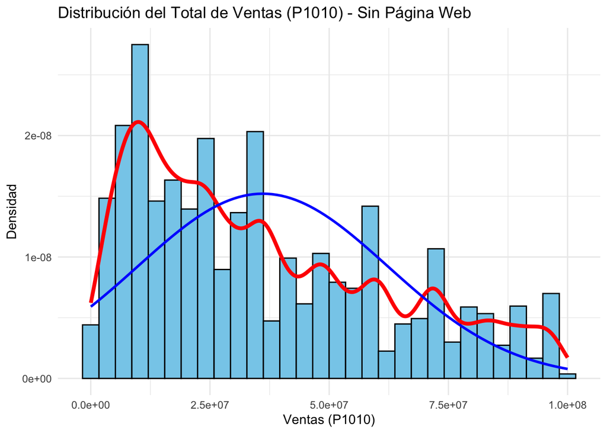

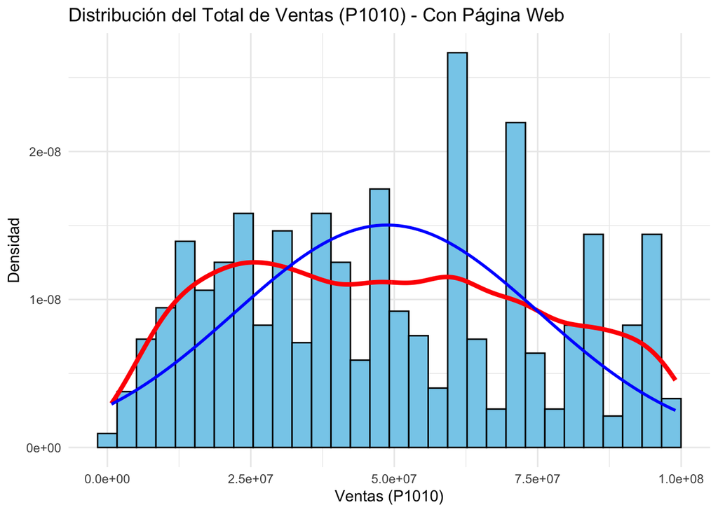

[output not shown]

```
##      Min.   1st Qu.    Median      Mean   3rd Qu.      Max.
##     20000  18000000  40000000  62040397  85000000 299844000
```

```
##      P1010 P2532 P1087 P1088 P1057 P1092 P2524 P1093 P1006 P1764 P1094
## 1 1.62e+08  <NA>     0     0    10     0     2    NA    NA    NA    NA
## 2 2.30e+07  <NA>     0     0    10     0     2    NA    NA    NA    NA
## 3 9.00e+07  <NA>     0     0    10     0     1     1    NA    NA     2
## 4 3.60e+07  <NA>     0     0    10     0     2    NA    NA    NA    NA
## 5 4.80e+07  <NA>     0     0    10     0     2    NA    NA    NA    NA
## 6 5.50e+07  <NA>     0     0    10     0     2    NA    NA    NA    NA
##   CDGO_DPRTMNTO
## 1             5
## 2             5
## 3             5
## 4             5
## 5             5
## 6             5
```

```
## [1] 30921
```

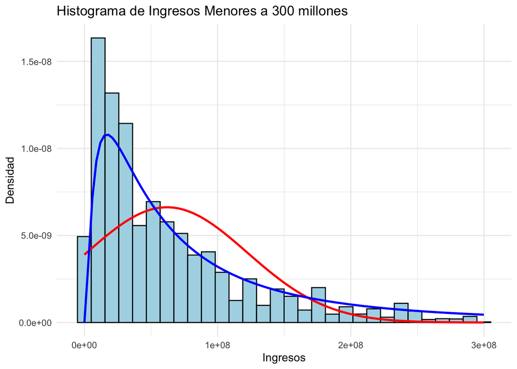

```
## [1] 17.9433
```

```
## [1] 1.14008
```

Para calcular la probabilidad de que los ingresos sean mayores de 100 millones, dado que siguen una distribución lognormal tenemos que:

Transformar el límite de ingresos: Debemos convertir 100 millones a la escala logarítmica usando la función de logaritmo natural (ln). x=ln(100,000,000)≈18.4207

Calcular la probabilidad: Usamos la media (μ) y la desviación estándar (σ) de la distribución lognormal encontrada arriba, que son
$$\mu=17.9433$$
y
$$\sigma=1.14008$$

La probabilidad de que los ingresos sean mayores de 100 millones, dado que siguen una distribución lognormal con un logmean de 17.9433 y un sdlog de 1.14008, es aproximadamente 0.3377, o 33.77%.

# 6 Estrategias

Desarrollar una estrategia basada en el análisis de las variables seleccionadas nos permite enfocarnos en varios aspectos clave que ayudarán a mejorar el desempeño de los microestablecimientos en Colombia, como los siguientes:

Estrategia 1: Mejorar la Adopción Tecnológica Fomentar la creación y mantenimiento de páginas web para los establecimientos que aún no tienen una. Esto puede aumentar la visibilidad y atraer a más clientes. También se puede promover el uso de Internet tanto dentro como fuera del establecimiento para mejorar la eficiencia operativa y la conectividad.

Estrategia 2: Optimización de Recursos Tecnológicos Evaluar la necesidad de actualizar o incrementar el número de computadores para mejorar la productividad. Incentivar el uso de dispositivos avanzados para tareas específicas que puedan beneficiarse al tener nuevas tecnologías.

Estrategia 3: Análisis Financiero y de Ventas Realizar un seguimiento constante de las ventas para identificar tendencias y áreas de mejora. Implementar estrategias de marketing y ventas basadas en estos datos. Utilizar esta información para ajustar estrategias de ventas y marketing según las variaciones estacionales o mensuales, considerando los efectos en proveedores y personal, para tomar decisiones basadas en los datos.

Estrategia 4: Formas de Pago Diversificar las formas de pago aceptadas para facilitar las transacciones y atraer a más clientes. Incluir opciones modernas como pagos móviles y billeteras digitales.

Estrategia 5: Análisis Regional Realizar análisis regionales para identificar las necesidades específicas de cada área y adaptar las estrategias en consecuencia. Por ejemplo, en regiones con altos costos de energía, se pueden buscar alternativas más eficientes o sostenibles.

Estrategia 6: Capacitación y Educación Es crucial mantenerse en constante capacitación dentro del nicho correspondiente para ofrecer mejores servicios y productos, alineados con la fuente de comercio del microestablecimiento. La capacitación debe incluir tanto el enfoque específico del establecimiento como conocimientos financieros y de optimización de recursos.

```
##
## ## Calcular el intervalo de confianza para el valor total de ventas o ingresos (P1010)
```

```
## Intervalo de confianza al 95% para el valor total de ventas promedio:
```

```
## Media: 97078679
```

```
## IC: 94995036 - 99162322
```

```
##
## ## Calcular el intervalo de confianza para la proporción de microestablecimientos con página web (P2532)
```

```
## Intervalo de confianza al 95% para la proporción de establecimientos con página web:
```

[output not shown]

```
## IC: NaN - NaN
```

```
##
## ## Estimación adicional 1: Proporción de microestablecimientos con acceso a Internet (P2524)
```

```
## Intervalo de confianza al 95% para la proporción de establecimientos con acceso a Internet:
```

[output not shown]

```
## IC: NaN - NaN
```

```
##
## ## Estimación adicional 2: Promedio de computadores portátiles en uso (P1088)
```

```
## Intervalo de confianza al 95% para el número promedio de computadores portátiles:
```

```
## Media: 0.09384182
```

```
## IC: 0.08955263 - 0.09813101
```

# 7 Limitaciones u oportunidades.

```
## Limitación 2: Falta de variables actualizadas sobre tecnología
```

```
## Una limitación del análisis es la falta de información más reciente sobre el uso de tecnologías modernas, como comercio electrónico o redes sociales, que podrían ser relevantes para el desempeño de los microestablecimientos.
```

```
## Las variables clave como 'Acceso a Internet (P2524)' no capturan el uso de tecnologías recientes como el comercio electrónico o redes sociales, lo que podría limitar el análisis.
```

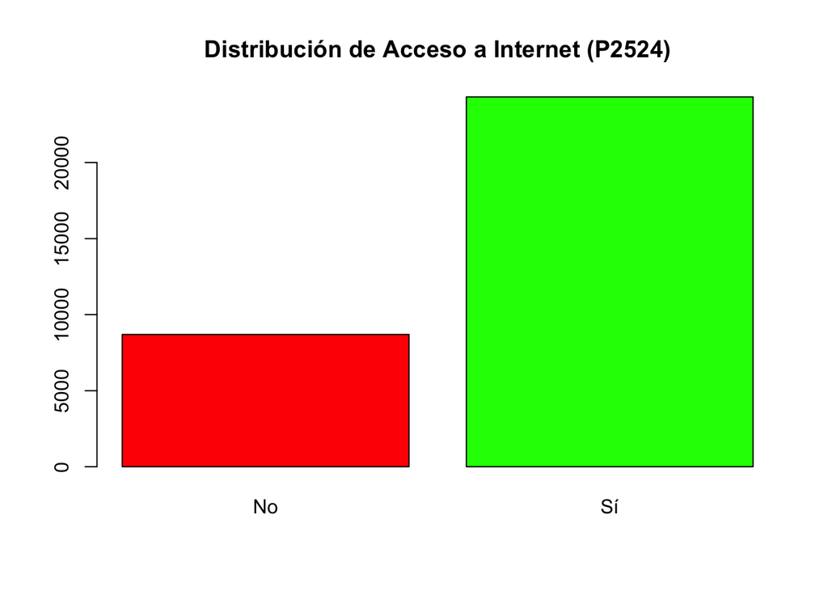

```
##
## Limitación 2: Alcance de las variables analizadas
```

[output not shown]

```
## Variables analizadas:
```

```
##  [1] "P1010"         "P2532"         "P1087"         "P1088"
##  [5] "P1057"         "P1092"         "P2524"         "P1093"
##  [9] "P1006"         "P1764"         "P1094"         "CDGO_DPRTMNTO"
```

```
##
## Oportunidad: Enriquecimiento del análisis con tecnologías emergentes
```

```
## Una oportunidad sería incluir variables relacionadas con la adopción de tecnologías emergentes, como el uso de inteligencia artificial, automatización y herramientas de comercio electrónico.
## Esto ayudaría a entender mejor cómo la modernización tecnológica impacta en los microestablecimientos y qué tecnologías tienen un mayor retorno de inversión.
```

# 8 Referencias.

Los datos utilizados para este análisis fueron obtenidos de la base de datos de microestablecimientos del DANE (2016). Más información puede ser consultada en: https://microdatos.dane.gov.co/index.php/catalog/560/data-dictionary/F10?file_name=Microestablecimientos_2016.\n”